# GitHub – version control

Zaya Delgerjargal

7/28/2020

## 1. Getting started with GitHub

Git is the version control system, the tool that tracks changes to our files over time.

Github is a hosting service for projects that use Git.

### 1.1. Registering a GitHub account

Before we can start using GitHub, we need to register our own GitHub account.

To register a new account, visit GitHub.com and find the ‘Sign up’ option on their website.

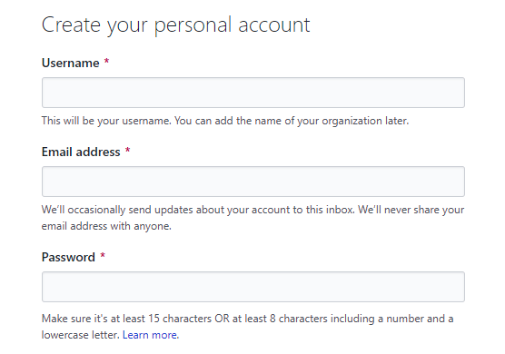

After that, verify your account via email.

### 1.2. What you’ll need

If you’re using Mac or Linux machine, you can utilize the default Bash terminal that comes pre-installed on your computer. If you’re using Windows, you can use its built-in Powershell terminal, or the Git Bash terminal. Here’s an instruction on how to do that: https://zarkom.net/blogs/how-to-install-git-and-git-bash-on-windows-9140

## 2. GitHub repositories

There can be many scenarios of how you may use GitHub, but the most common scenario would probably be you cloning an existing repository online.

Repository/Repo: a fancy name for a folder containing all code files.

Clone: to download a repo to your computer.

Let’s clone a repo and actually use GitHub!

**Step 1.** Log in to GitHub

**Step 2.** Go to https://github.com/energy-policy-institute-uchicago/learning-git and clone the repo “learning-git” from your Terminal:

```
git clone https://github.com/energy-policy-institute-uchicago/learning-git.git
```

**Step 3.** Make changes to the repo by either editing an existing file or creating new one.

```
git status
```

**Step 4.** Commit your changes! The following is called “staging a file.”

```
git add .
OR
git add <name_of_your_file>
```

The following is called “unstaging a file”:

```
git reset HEAD <name_of_your_file>
```

Now commit:

```
git commit -m <"Commit message">
```

See commit history:

```
git log
```

Go back to a previous state of your project:

```
git checkout <commit-hash>
```

Replace `<commit-hash>` with the actual hash for the specific commit that you want to visit, which is listed with the `git log` command. You can’t see the changes in the remote. YET.

**Step 5.** Push your changes.

```
git push {name_of_your_remote} {name_of_your_branch}
```

## 3. Branches

### 3.1. Creating a new branch

Fist, see which branch you’re using:

```
git branch
```

Next, pull from master:

```
git pull origin master
```

Then do:

```
git checkout -b <name_of_new_branch>
```

### 3.2. Changing branches

To switch to a different branch, you the `git checkout` command:

```
git checkout <branch_name>
```

### 3.3 Deleting a branch:

```
git branch -d <branch_name>
```

## 4. Futher Learning

To learn more about Git, make sure to check the following resources:

- Git official documentation: https://git-scm.com/doc
- The free **Pro Git** book: https://git-scm.com/book/en/v2
- Learn about GitHub: https://guides.github.com/